# Lab 5: Machine Learning in Hydrology with CAMELS

### 4e-Tuning

```r
rf_tune_spec <- rand_forest(
  mtry  = tune(),
  min_n = tune(),
  trees = 500
) |>
  set_engine("ranger", importance = "permutation") |>
  set_mode("regression")
```

```r
rf_workflow <- workflow() |>
  add_recipe(camels_recipe) |>
  add_model(rf_tune_spec)

# Use the workflow to extract sensible parameter ranges, then build a
# space-filling Latin hypercube grid. mtry's upper bound has to be set
# explicitly because it depends on the number of predictors (8 here).
rf_params <- extract_parameter_set_dials(rf_workflow) |>
  update(mtry = mtry(range = c(1L, 8L)))

rf_grid <- grid_space_filling(rf_params, size = 25)

rf_grid
```

```
# A tibble: 25 × 2
    mtry min_n
   <int> <int>
 1     1    24
 2     1    13
 3     1    33
 4     1     5
 5     2    19
 6     2    27
 7     2    36
 8     3    11
 9     3     3
10     3    21
# ℹ 15 more rows
```

```r
set.seed(456)

rf_tune_results <- tune_grid(
  rf_workflow,
  resamples = folds_spatial,
  grid      = rf_grid,
  control   = control_grid(save_pred = TRUE, save_workflow = TRUE),
  metrics   = metric_set(rmse, rsq, mae)
)
```

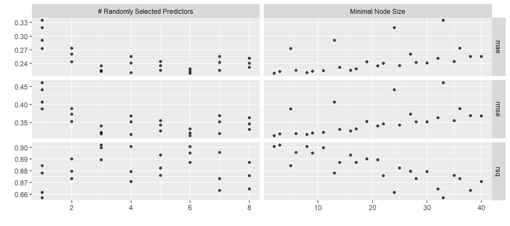

```r
autoplot(rf_tune_results)
```

```r
show_best(rf_tune_results, metric = "rsq", n = 5)
```

```
# A tibble: 5 × 8
   mtry min_n .metric .estimator  mean     n std_err .config
  <int> <int> <chr>   <chr>      <dbl> <int>   <dbl> <chr>
1     3     3 rsq     standard   0.902    10  0.0156 pre0_mod08_post0
2     4     8 rsq     standard   0.901    10  0.0159 pre0_mod11_post0
3     6     2 rsq     standard   0.901    10  0.0172 pre0_mod17_post0
4     3    11 rsq     standard   0.900    10  0.0161 pre0_mod09_post0
5     7     6 rsq     standard   0.896    10  0.0186 pre0_mod20_post0
```

```r
best_rf_params <- select_best(rf_tune_results, metric = "rsq")
best_rf_params
```

```
# A tibble: 1 × 3
   mtry min_n .config
  <int> <int> <chr>
1     3     3 pre0_mod08_post0
```

```r
best_rf_params <- select_best(rf_tune_results, metric = "rsq")
best_rf_params
```

```
# A tibble: 1 × 3
   mtry min_n .config
  <int> <int> <chr>
1     3     3 pre0_mod08_post0
```

```r
# Finalize the workflow with the chosen hyperparameters
final_rf_workflow <- finalize_workflow(rf_workflow, best_rf_params)
final_rf_workflow
```

```
══ Workflow ════════════════════════════════════════════════════════════════════
Preprocessor: Recipe
Model: rand_forest()

── Preprocessor ────────────────────────────────────────────────────────────────
5 Recipe Steps

• step_naomit()
• step_log()
• step_YeoJohnson()
• step_normalize()
• step_zv()

── Model ───────────────────────────────────────────────────────────────────────
Random Forest Model Specification (regression)

Main Arguments:
  mtry = 3
  trees = 500
  min_n = 3

Engine-Specific Arguments:
  importance = permutation

Computational engine: ranger
```

Tuned mtry and min_n over a 25-point Latin hypercube grid against 10-fold spatial block CV; trees was held at 500 (a budget knob, not a sensitivity knob). Latin hypercube was chosen over a regular grid because it covers the 2D hyperparameter space more uniformly for the same fit budget. The best combination was mtry = 3, min_n = 3 (spatial CV R² = 0.902, RMSE = 0.32), with the top four candidates within 0.002 R² of each other, well inside the per-fold standard error of ~0.016, indicating the result is a plateau rather than a sharp optimum. The tuning landscape shows that mtry was the dominant hyperparameter: performance was clearly worst at mtry = 1 and roughly flat from mtry = 3 onward, while min_n had a much weaker effect with only a slight preference for smaller terminal nodes (3–11). This pattern matches the random-forest literature: mtry controls the bias-variance tradeoff between tree decorrelation and individual tree strength, and once enough predictors are sampled per split (here, ~⅜ of 8) the model’s accuracy is largely insensitive to further adjustment. Tuning gained ~0.004 R² over the default specification, a real but modest improvement, consistent with random forest being a strong default-performer.